# General Linear Model (1)

The `mosaic` package contains dataframe `Births78`

A day by day record of the number of births in the United States in 1978.

```r
library(mosaic)
head(Births78); summary(Births78$births)
```

```
        date births wday year month day_of_year day_of_month day_of_week
1 1978-01-01   7701  Sun 1978     1           1            1           1
2 1978-01-02   7527  Mon 1978     1           2            2           2
3 1978-01-03   8825  Tue 1978     1           3            3           3
4 1978-01-04   8859  Wed 1978     1           4            4           4
5 1978-01-05   9043  Thu 1978     1           5            5           5
6 1978-01-06   9208  Fri 1978     1           6            6           6
```

```
   Min. 1st Qu.  Median    Mean 3rd Qu.    Max.
   7135    8554    9218    9132    9705   10711
```

## Births by date: \(\quad\) interpretation?

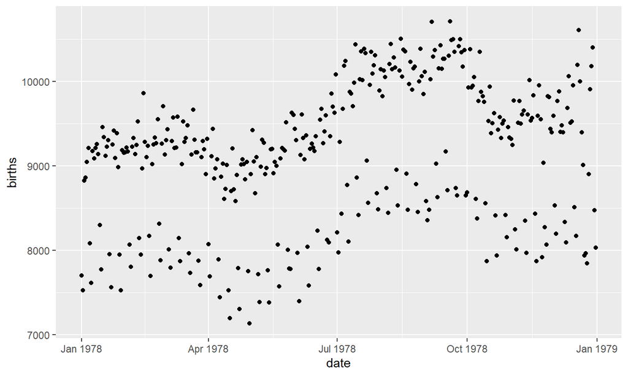

```r
library(ggformula)
gf_point(births ~ date , data = Births78)
```

## Working days

```r
d <- Births78 %>%
  select(-year) %>%
  # new variable day (Work/Sun/Sat)
  mutate(day = ifelse(wday %in% c("Sun", "Sat"),
                      as.character(wday),                         # note as.character()
                      "Work"),
         day = factor(day, levels = c("Work", "Sat", "Sun")))     # define as factor
head(d)
```

```
        date births wday month day_of_year day_of_month day_of_week  day
1 1978-01-01   7701  Sun     1           1            1           1  Sun
2 1978-01-02   7527  Mon     1           2            2           2 Work
3 1978-01-03   8825  Tue     1           3            3           3 Work
4 1978-01-04   8859  Wed     1           4            4           4 Work
5 1978-01-05   9043  Thu     1           5            5           5 Work
6 1978-01-06   9208  Fri     1           6            6           6 Work
```

## Explaining the variability of births

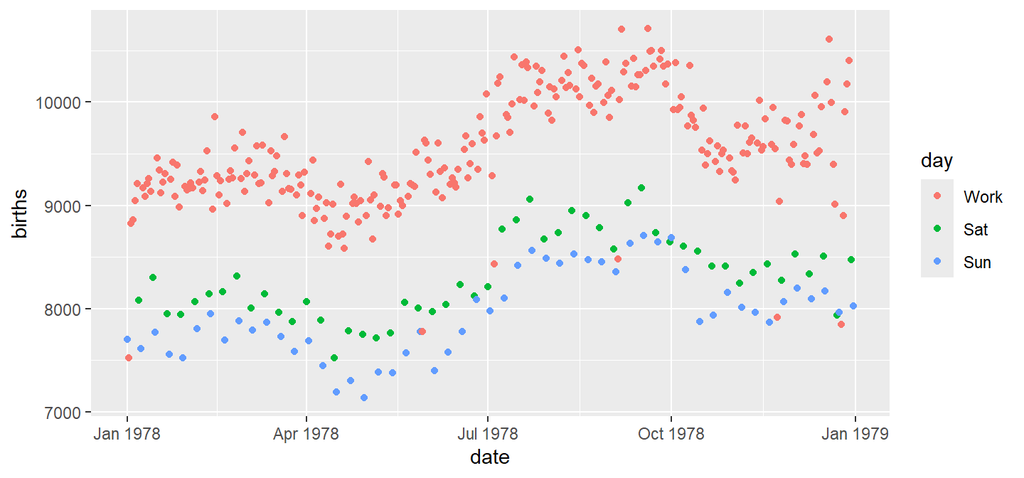

```r
gf_point(births ~ date, col= ~ day, data = d)
```

- Day: working, saturday or sunday
- Month: increasing trend, but non-linear, non-monotonic

## A first model, based on day

```r
mod_d <- lm(births ~ day, data = d)
summary(mod_d)
```

```
Call:
lm(formula = births ~ day, data = d)

Residuals:
     Min       1Q   Median       3Q      Max
-2010.52  -341.52   -57.52   400.48  1173.48

Coefficients:
            Estimate Std. Error t value Pr(>|t|)
(Intercept)  9537.52      31.20  305.70   <2e-16 ***
daySat      -1228.19      76.42  -16.07   <2e-16 ***
daySun      -1586.57      75.82  -20.93   <2e-16 ***
---
Signif. codes:  0 '***' 0.001 '**' 0.01 '*' 0.05 '.' 0.1 ' ' 1

Residual standard error: 503.1 on 362 degrees of freedom
Multiple R-squared:  0.6238,    Adjusted R-squared:  0.6217
F-statistic: 300.1 on 2 and 362 DF,  p-value: < 2.2e-16
```

## Model coefficients: \(\quad\) interpretation

If explanatory variable is a factor:

- Intercept: \(\qquad \quad\) the mean of `births` in the *reference level* (`Working`)
- daySat, daySun: \(\quad\) the difference of mean `births` wrt *reference level*

```r
coef(mod_d)                    # extract coefficients from model mpd_day
```

```
(Intercept)      daySat      daySun
   9537.515   -1228.188   -1586.572
```

```r
mean(births ~ day, data = d)     # means by day
```

```
    Work      Sat      Sun
9537.515 8309.327 7950.943
```

## Model coefficients: \(\quad\) 95% CI’s

```r
coef(mod_d)
```

```
(Intercept)      daySat      daySun
   9537.515   -1228.188   -1586.572
```

```r
confint(mod_d)           # gets the 95% confidence intervals for coefficients
```

```
                2.5 %    97.5 %
(Intercept)  9476.162  9598.869
daySat      -1378.474 -1077.903
daySun      -1735.671 -1437.473
```

## Goodness-of-fit: \(\quad\) R-squared

Total variability = Explained (by day) + Residual

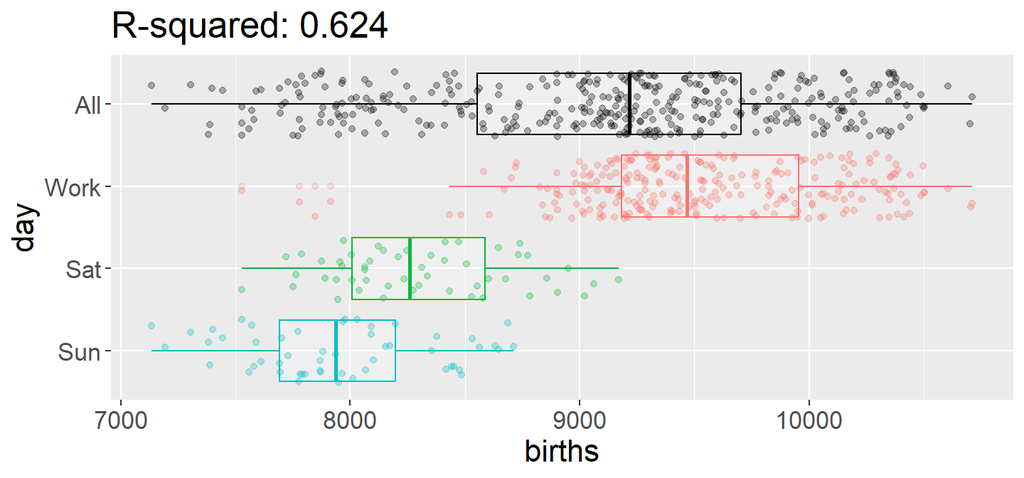

62.4 % of the total variability of `births` is explained by `day`.

The higher the R-squared value, the better the fit.

## The first model, graphically

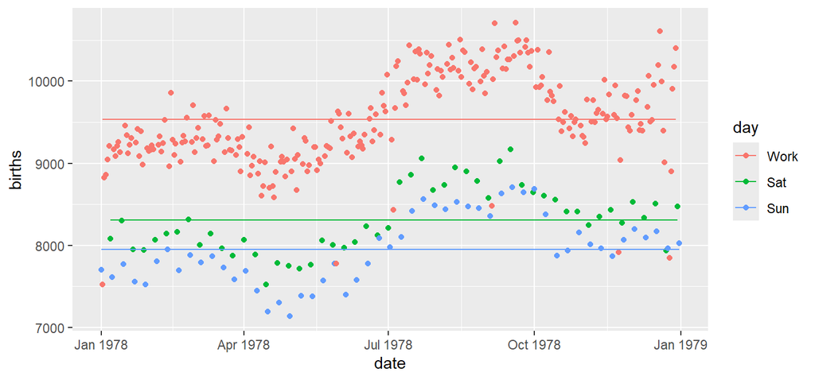

```r
d$pred <- predict(mod_d)                                # get predicted values

gf_point(births ~ date, col = ~ day, data = d) %>%
  gf_line(pred ~ date)                                  # add them to plot
```

## A second model, adding month

```r
mod_dm <- lm(births ~ day + month, data = d); summary(mod_dm)
```

```
Call:
lm(formula = births ~ day + month, data = d)

Residuals:
    Min      1Q  Median      3Q     Max
-2084.6  -281.0    -5.3   304.2   995.1

Coefficients:
             Estimate Std. Error t value Pr(>|t|)
(Intercept)  9071.723     51.142  177.38   <2e-16 ***
daySat      -1235.897     66.604  -18.56   <2e-16 ***
daySun      -1588.047     66.074  -24.03   <2e-16 ***
month          71.576      6.656   10.75   <2e-16 ***
---
Signif. codes:  0 '***' 0.001 '**' 0.01 '*' 0.05 '.' 0.1 ' ' 1

Residual standard error: 438.4 on 361 degrees of freedom
Multiple R-squared:  0.715, Adjusted R-squared:  0.7127
F-statistic: 301.9 on 3 and 361 DF,  p-value: < 2.2e-16
```

## Model coefficients: \(\quad\) interpretation

If explanatory variable is numeric, the coefficient is a **slope**:

- There is a 71.6 increase in `births` per unit increase in month

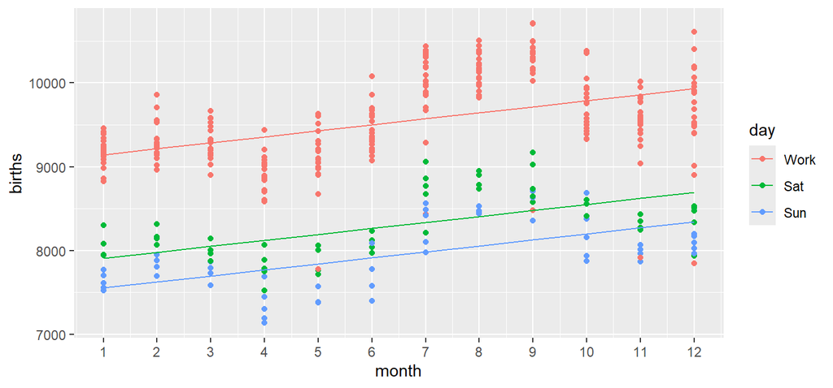

## The second model, graphically

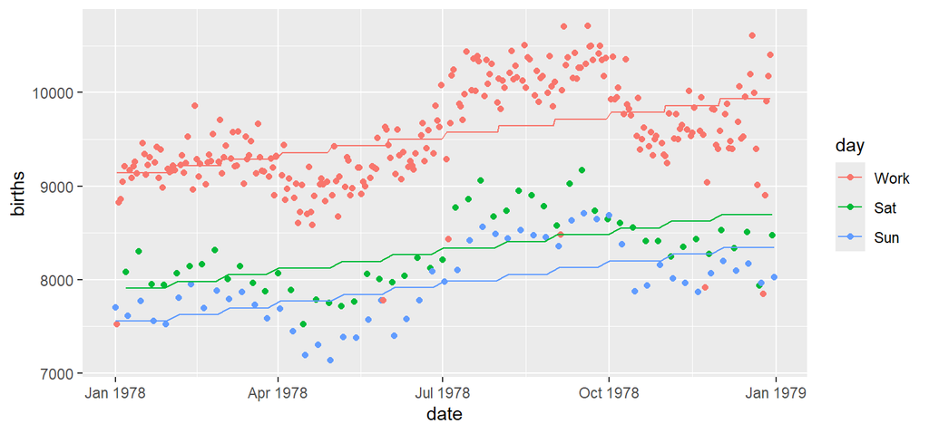

```r
d$pred <- predict(mod_dm)                               # get predicted values

gf_point(births ~ date, col = ~ day, data = d) %>%
  gf_line(pred ~ date)                                  # add predicted values to plot
```

## A third model, using polynomials for month

```r
mod_dm5 <- lm(births ~ day + poly(month,5), data = d); summary(mod_dm5)
```

```
Call:
lm(formula = births ~ day + poly(month, 5), data = d)

Residuals:
     Min       1Q   Median       3Q      Max
-1814.31  -145.48    19.24   152.71   944.69

Coefficients:
                Estimate Std. Error t value Pr(>|t|)
(Intercept)      9538.46      19.89 479.440  < 2e-16 ***
daySat          -1238.47      48.74 -25.409  < 2e-16 ***
daySun          -1582.98      48.35 -32.738  < 2e-16 ***
poly(month, 5)1  4714.94     320.79  14.698  < 2e-16 ***
poly(month, 5)2 -1902.69     320.81  -5.931 7.12e-09 ***
poly(month, 5)3 -3730.60     320.79 -11.629  < 2e-16 ***
poly(month, 5)4   467.22     320.80   1.456    0.146
poly(month, 5)5  3859.82     320.81  12.032  < 2e-16 ***
---
Signif. codes:  0 '***' 0.001 '**' 0.01 '*' 0.05 '.' 0.1 ' ' 1

Residual standard error: 320.8 on 357 degrees of freedom
Multiple R-squared:  0.8491,    Adjusted R-squared:  0.8462
F-statistic:   287 on 7 and 357 DF,  p-value: < 2.2e-16
```

## The third model: \(\quad\) polynomials for month

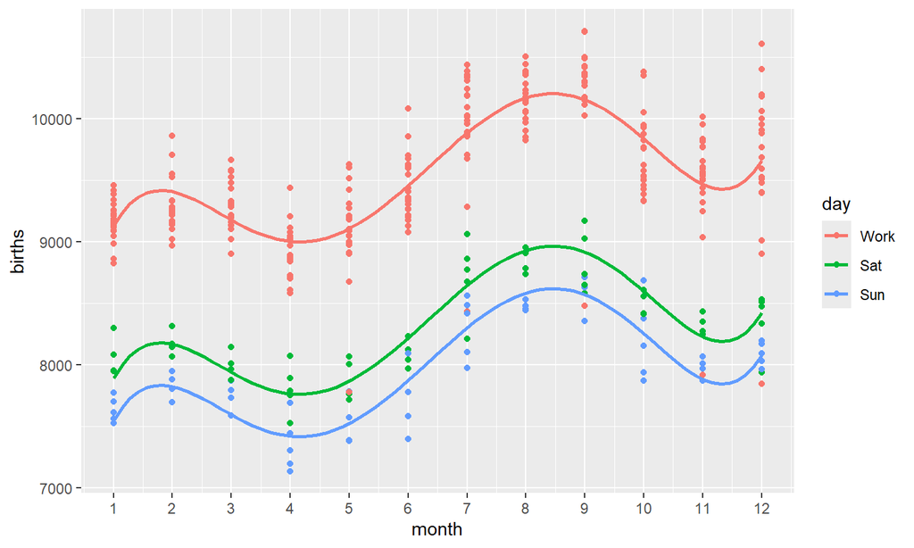

## The third model, graphically

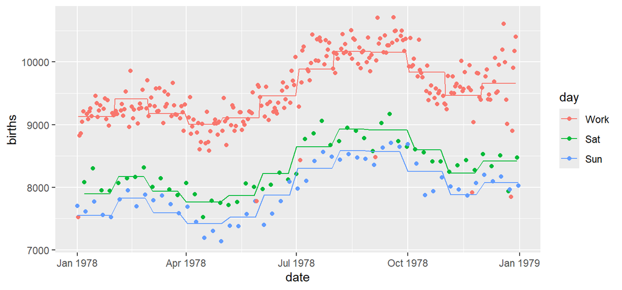

```r
d$pred <- predict(mod_dm5)                      # get predicted values

gf_point(births ~ date, col= ~ day, data = d) %>%
  gf_line(pred ~ date, col = ~day)              # add predicted values to plot
```

## Comparing nested models

Two models are nested if one is contained in the other

```r
anova(mod_d, mod_dm, mod_dm5)                          # compare models
```

```
Analysis of Variance Table

Model 1: births ~ day
Model 2: births ~ day + month
Model 3: births ~ day + poly(month, 5)
  Res.Df      RSS Df Sum of Sq       F    Pr(>F)
1    362 91613273
2    361 69386798  1  22226475 216.006 < 2.2e-16 ***
3    357 36734358  4  32652440  79.332 < 2.2e-16 ***
---
Signif. codes:  0 '***' 0.001 '**' 0.01 '*' 0.05 '.' 0.1 ' ' 1
```

- Significant improvement in fit by adding month (Model 2)
- Significant improvement in fit by adding polynomial terms for month (Model 3)

## Execise

1. With the `births` dataset, fit a model with predictors
   - `day`, and
   - `day_of_year` (instead of `month`) using 5-degree polynomials
2. Get the summary of the model and look at R-squared
3. Show the model graphically
4. Comparing this model to the previous one (using `month`), which one do you prefer, and why?